# Exploratory_Document

Dario J C

02/05/2021

## Exploratory Analysis

The following are questions which were deemed important in the analysis

- What does the data look like?

  The data given is found at this [link](https://d396qusza40orc.cloudfront.net/dsscapstone/dataset/Coursera-SwiftKey.zip) which is a zip file and includes 12 text files. Our interest is three of these files which are primarily in english and are taken based on blogs, news, and twitter respectively.  
  Although the original description says differently, we can check and see the files themselves do not include in their text any descriptors which can be used to track heir sources. I believe we were given a small subset of the original data to work on.
- Where does the data come from?

  The was collected from publicly available sources by a web crawler which in its editing included parsing further, to remove duplicate entries and split into individual lines. A link to the original description can be found [here](http://web.archive.org/web/20160930083655/http://www.corpora.heliohost.org/aboutcorpus.html).
- What interesting key notes did you find in the data?

  I found that the data has more text from the blogs, rather than twitter or the news. The news source has n-grams which don’t rely on colloqial language, or slang (e.g. contractions or the use of ‘lol’ or ‘rt’) as much as the blog or twitter does. The concern regarding foreign languages in the text seems ignorable for the most part as they don’t heavily influence the top n-grams, but cleaning is still needed as we have the use of specicif slang (e.g. ‘rt please’) and single letter words which still show themselves. Further details can be found below.

### Download the Data

For our Exploratory analysis, we will be primarily working with the **quanteda** package, but will switch to **ggplot2** for visualizations.

We used the function `stri_split_lines1` to read in our text files as characters for each line. This is then fed into the `corpus` function to build a corpus for us to analyse.

```r
library(tidyverse)

library(quanteda)

library(readtext)
library(stringi)
```

```r
# Get working directory
dir <- getwd()

# Name file being downloading
zip_file <- "Coursera-SwiftKey.zip"


if( !any(list.files() == "Coursera-SwiftKey.zip")){

  # Link to file to download
  dl_url <- "https://d396qusza40orc.cloudfront.net/dsscapstone/dataset/Coursera-SwiftKey.zip"

  # Create place file to be downloaded to
  zip_loc <- as.character(paste(dir, zip_file, sep = "/"))

  # Download file
  download.file(dl_url,
                destfile = zip_loc)

  rm(list = c("dl_url",
              "zip_loc"))
}


if( !any(str_detect(list.dirs(), "final/en_US"))){
  # Unzip file
  unzip(zip_file)
}

# Get paths to see where the file we want are located
paths <- list.dirs()
# Ensure we pull only the path to the files we want
used_path <- paths[str_detect(paths, "en_US")]
# Open the file we're interested in
setwd(used_path)



# Create corpus, where each line is a document
full_text_blog <- stri_split_lines1(readtext("en_US.blogs.txt"))
full_text_news <- stri_split_lines1(readtext("en_US.news.txt"))
full_text_twitter <- stri_split_lines1(readtext("en_US.twitter.txt"))


prop <- 1
prop_blog <- round( length(full_text_blog) * prop)
prop_news <- round( length(full_text_news) * prop)
prop_twitter <- round( length(full_text_twitter) * prop)

set.seed(123)
index_blog <- sample(1:length(full_text_blog), prop_blog, replace = FALSE)
index_news <- sample(1:length(full_text_news), prop_news, replace = FALSE)
index_twitter <- sample(1:length(full_text_twitter), prop_twitter, replace = FALSE)

corpus_blog <- corpus(full_text_blog[index_blog])
corpus_news <- corpus(full_text_news[index_news])
corpus_twitter <- corpus(full_text_twitter[index_twitter])


# Move back to old work directory
setwd(dir)

# Clean up
rm(list = c("dir",
            "paths",
            "used_path",
            "zip_file",
            "prop",
            "prop_blog",
            "prop_news",
            "prop_twitter",
            "full_text_blog",
            "full_text_news",
            "full_text_twitter",
            "index_blog",
            "index_news",
            "index_twitter"))
```

### Basic Statistics

We will generate some basic statistics to better understand what exactly we’re looking at.

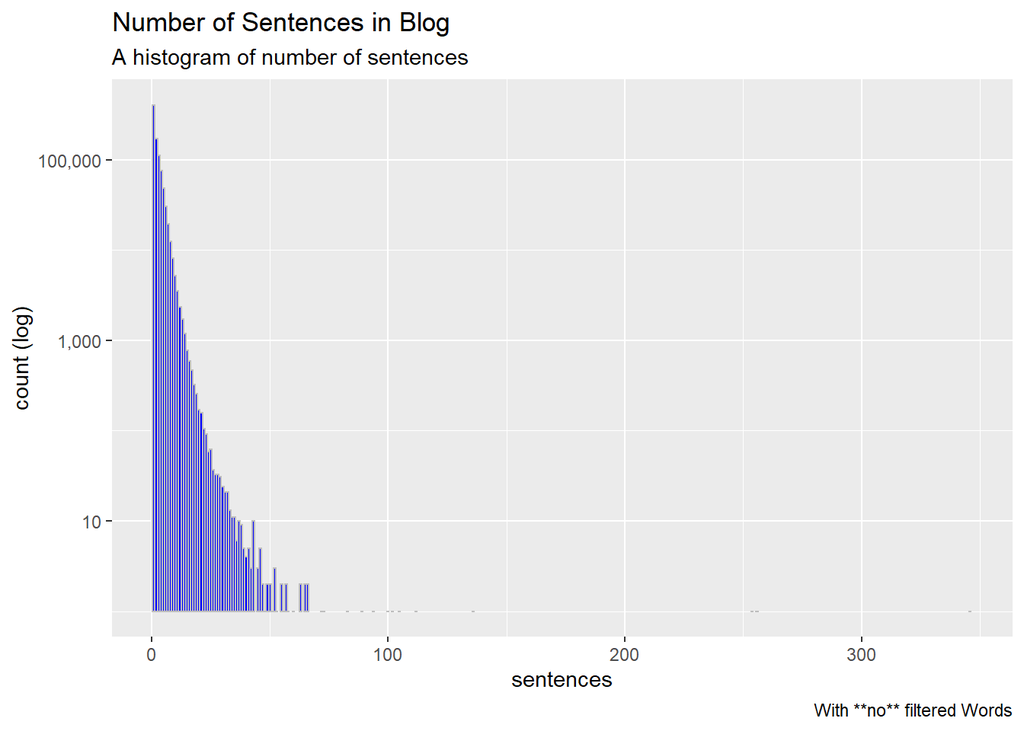

```r
# Count words
word_length_blog <- ntoken(tokens(corpus_blog,
                            what = "word",
                            remove_punct = TRUE,
                            remove_url = TRUE))
word_length_news <- ntoken(tokens(corpus_news,
                             what = "word",
                             remove_punct = TRUE,
                             remove_url = TRUE))
word_length_twitter <- ntoken(tokens(corpus_twitter,
                             what = "word",
                             remove_punct = TRUE,
                             remove_url = TRUE))

# Count sentences
sentence_length_blog <- nsentence(corpus_blog)
sentence_length_news <- nsentence(corpus_news)
sentence_length_twitter <- nsentence(corpus_twitter)

## Plot sentences

# Plot for blog
as.data.frame(sentence_length_blog) %>%
  filter(sentence_length_blog != 0) %>%
  ggplot(aes(x = sentence_length_blog)) +
  geom_histogram(fill = 'blue',
                 colour = 'grey',
                 binwidth = 1) +
  scale_y_log10(labels = scales::comma) +
  labs(title = 'Number of Sentences in Blog',
       x = 'sentences',
       y = 'count (log)',
       subtitle = 'A histogram of number of sentences',
       caption = 'With **no** filtered Words')
```

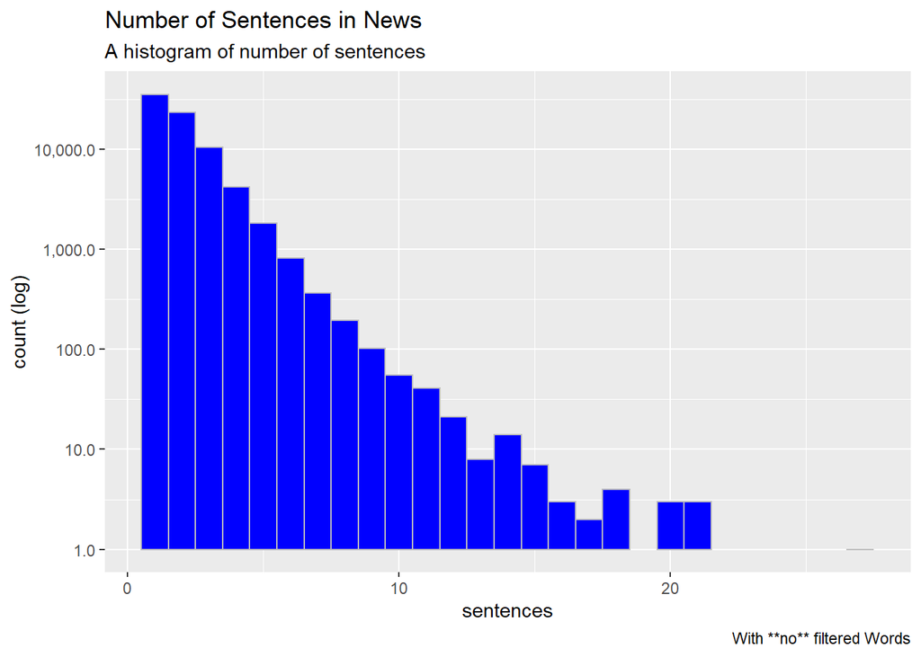

```r
# Plot for news
as.data.frame(sentence_length_news) %>%
  filter(sentence_length_news != 0) %>%
  ggplot(aes(x = sentence_length_news)) +
  geom_histogram(fill = 'blue',
                 colour = 'grey',
                 binwidth = 1) +
  scale_y_log10(labels = scales::comma) +
  labs(title = 'Number of Sentences in News',
       x = 'sentences',
       y = 'count (log)',
       subtitle = 'A histogram of number of sentences',
       caption = 'With **no** filtered Words')
```

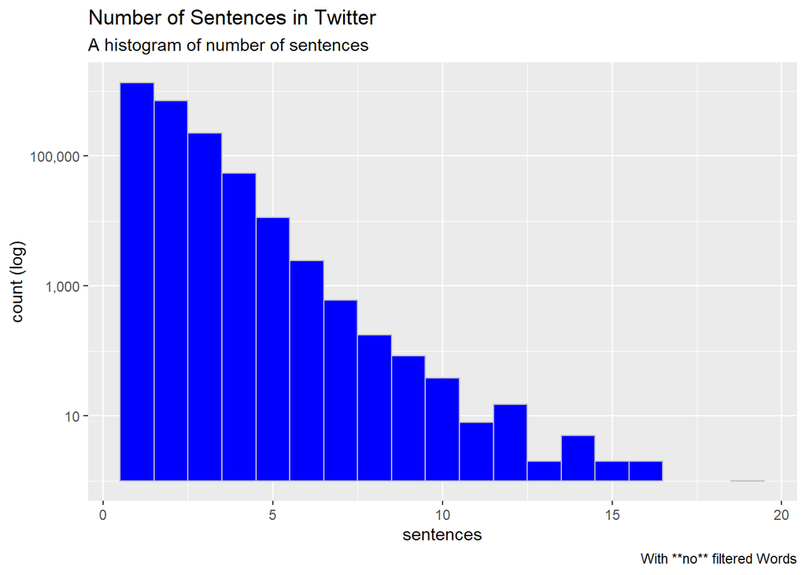

```r
# Plot for twitter
as.data.frame(sentence_length_twitter) %>%
  filter(sentence_length_twitter != 0) %>%
  ggplot(aes(x = sentence_length_twitter)) +
  geom_histogram(fill = 'blue',
                 colour = 'grey',
                 binwidth = 1) +
  scale_y_log10(labels = scales::comma) +
  labs(title = 'Number of Sentences in Twitter',
       x = 'sentences',
       y = 'count (log)',
       subtitle = 'A histogram of number of sentences',
       caption = 'With **no** filtered Words')
```

```r
if(!any(ls() == "basic_stats")){

# Dataframe of basic stats
basic_stats <- data.frame(
  source = c ("blog",
              "news",
              "twitter"),
  num_rows = c(length(corpus_blog),
               length(corpus_news),
               length(corpus_twitter)),
  num_words = c(sum(word_length_blog),
                    sum(word_length_news),
                    sum(word_length_twitter)),
  num_sentences = c(sum(sentence_length_blog),
                    sum(sentence_length_news),
                    sum(sentence_length_twitter))
)

}

# Show table
basic_stats %>%
  gt::gt() %>%
  gt::fmt_number(
    columns = 2:4,
    use_seps = TRUE,
  )
```

| source | num_rows | num_words | num_sentences |
| --- | --- | --- | --- |
| blog | 899,288.00 | 39,159,173.00 | 2,342,260.00 |
| news | 77,259.00 | 2,693,664.00 | 151,867.00 |
| twitter | 2,360,148.00 | 30,393,405.00 | 3,750,277.00 |

```r
rm(list = "word_length_blog",
   "word_length_news",
   "word_length_twitter",
   "sentence_length_blog",
   "sentence_length_news",
   "sentence_length_twitter")
```

Our plots show us most of the text we have are single sentences, this makes sense as we’re told in the data description that the data was parsed and 50% of the original scraped information has been removed. We are left with what seems to be independent sentences.

We also can see that the blog gives us the most text.

### Create Tokens

Continuing our exploratory phase, we create our tokens to better understand word layout.

```r
# Create tokens
token_blog <- tokens(corpus_blog)
token_news <- tokens(corpus_news)
token_twitter <- tokens(corpus_twitter)
```

### Generate Visualisation

We will now start to remove uninteresting components from our corpus to better visualise what’s occurring. These components are:

1. punctuation
2. symbols
3. numbers
4. urls
5. stopwords

You may notice I haven’t removed profanity. I choose not to as this is still the exploratory phase and I wished to see if it would change any of the details we find.

We’ll then create a **dfm** (document-feature matrix) to help us do some frequency analysis and see what words and **n-grams** sticks out.

For reference, a dfm puts the documents into a matrix format. The rows are the original texts and the columns are the features of that text, which may be tokens.

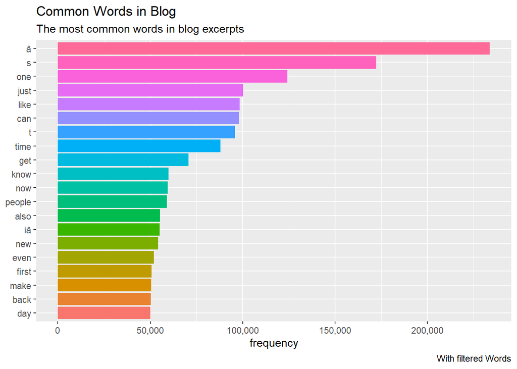

```r
# Clean tokens
token_blog_cleaned <- tokens_remove(tokens(token_blog,
                                           remove_punct = TRUE,
                                           remove_symbols = TRUE,
                                           remove_numbers = TRUE,
                                           remove_url = TRUE,
                                           padding = TRUE
                                           ),
                                    padding = TRUE,
                                    stopwords("english"))

token_news_cleaned <- tokens_remove(tokens(token_news,
                                           remove_punct = TRUE,
                                           remove_symbols = TRUE,
                                           remove_numbers = TRUE,
                                           remove_url = TRUE,
                                           padding = TRUE
                                           ),
                                    padding = TRUE,
                                    stopwords("english"))

token_twitter_cleaned <- tokens_remove(tokens(token_twitter,
                                           remove_punct = TRUE,
                                           remove_symbols = TRUE,
                                           remove_numbers = TRUE,
                                           remove_url = TRUE,
                                           padding = TRUE
                                           ),
                                    padding = TRUE,
                                    stopwords("english"))

# Create a DFM
dfmat_blog <- dfm(token_blog_cleaned)
dfmat_news <- dfm(token_news_cleaned)
dfmat_twitter <- dfm(token_twitter_cleaned)

# Get frequency statistics
freq_blog <- quanteda.textstats::textstat_frequency(dfmat_blog)
freq_news <- quanteda.textstats::textstat_frequency(dfmat_news)
freq_twitter <- quanteda.textstats::textstat_frequency(dfmat_twitter)

# Create visualisations for single words
freq_blog %>%
  # remove 'uninteresting' words
  # filter(2 < str_length(feature)) %>%
  filter(feature != "") %>%
  slice_head(n = 20) %>%
  mutate(feature = factor(feature),
         feature = fct_reorder(feature, frequency, min)) %>%
  ggplot(aes(x = feature, y = frequency, fill = feature)) +
  scale_y_continuous(labels = scales::comma) +
  geom_col(show.legend = FALSE) +
  coord_flip() +
  labs(title = 'Common Words in Blog',
       x = NULL,
       subtitle = 'The most common words in blog excerpts',
       caption = 'With filtered Words')
```

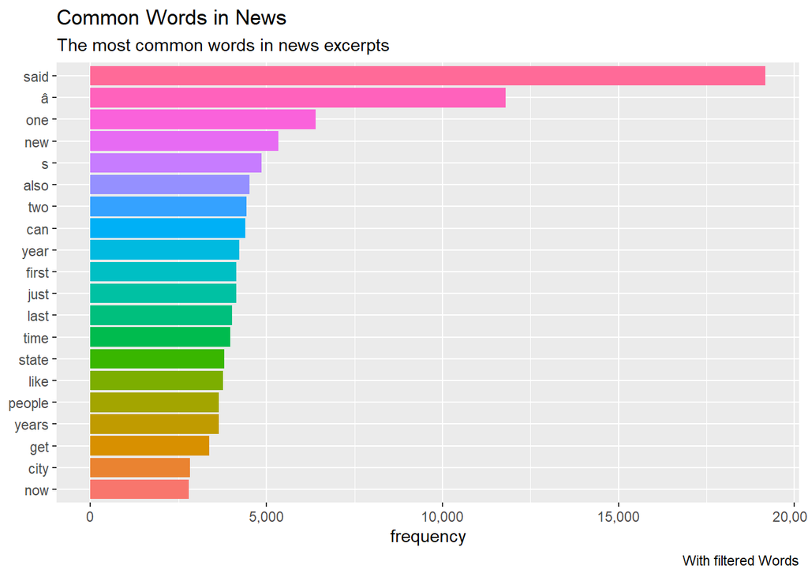

```r
freq_news %>%
  # remove 'uninteresting' words
  # filter(2 < str_length(feature)) %>%
  filter(feature != "") %>%
  slice_head(n = 20) %>%
  mutate(feature = factor(feature),
         feature = fct_reorder(feature, frequency, min)) %>%
  ggplot(aes(x = feature, y = frequency, fill = feature)) +
  scale_y_continuous(labels = scales::comma) +
  geom_col(show.legend = FALSE) +
  coord_flip() +
  labs(title = 'Common Words in News',
       x = NULL,
       subtitle = 'The most common words in news excerpts',
       caption = 'With filtered Words')
```

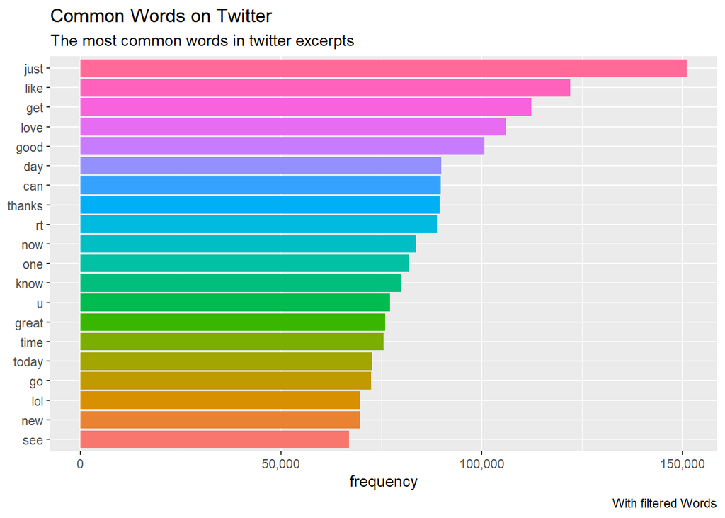

```r
freq_twitter %>%
  # remove 'uninteresting' words
  # filter(2 < str_length(feature)) %>%
  filter(feature != "") %>%
  slice_head(n = 20) %>%
  mutate(feature = factor(feature),
         feature = fct_reorder(feature, frequency, min)) %>%
  ggplot(aes(x = feature, y = frequency, fill = feature)) +
  scale_y_continuous(labels = scales::comma) +
  geom_col(show.legend = FALSE) +
  coord_flip() +
  labs(title = 'Common Words on Twitter',
       x = NULL,
       subtitle = 'The most common words in twitter excerpts',
       caption = 'With filtered Words')
```

We can see from the graph that the distributions are pretty interesting for each source.

For the blog, we see the word ‘one’ is distinctly most used. With the news, the word ‘said’ is the highest, followed by ‘one’, to be frank this agrees with my preconceptions as the news in my opinion includes a great deal of citing sources which includes “X ‘said’ so and so”.

Twitter on the other hand seems the least biased with chosen words and ‘just’ is the first word listed.

You can also see a lot more slang being used, for example ‘lol’, ‘rt’ or ‘u’. I’m not sure how I will treat them at the moment, I’m currently leaning towards excluding them from predictions.

What I’d like to point out is that they’re some oddities. You may notice I didn’t speak about ‘â’ or the single letter inclusions which should not be with the current token removals. I’ll have to deal with those when designing the model, likely by removing one letter words, except for ‘I’ and ‘a’.

#### N-gram Generation

We’ll now create our n-grams and visualise them as well.

```r
# Create bi-grams, n = 2
dfmat_bi_blog <- token_blog_cleaned %>% tokens_ngrams(2) %>% dfm()
dfmat_bi_news <- token_news_cleaned %>% tokens_ngrams(2) %>% dfm()
dfmat_bi_twitter <- token_twitter_cleaned %>% tokens_ngrams(2) %>% dfm()

# Get frequency statistics for bi-grams
freq_bi_blog <- quanteda.textstats::textstat_frequency(dfmat_bi_blog)
freq_bi_news <- quanteda.textstats::textstat_frequency(dfmat_bi_news)
freq_bi_twitter <- quanteda.textstats::textstat_frequency(dfmat_bi_twitter)



# Create tri-grams, n = 3
dfmat_tri_blog <- token_blog_cleaned %>% tokens_ngrams(3) %>% dfm()
dfmat_tri_news <- token_news_cleaned %>% tokens_ngrams(3) %>% dfm()
dfmat_tri_twitter <- token_twitter_cleaned %>% tokens_ngrams(3) %>% dfm()

# Get frequency statistics for tri-grams
freq_tri_blog <- quanteda.textstats::textstat_frequency(dfmat_tri_blog)
freq_tri_news <- quanteda.textstats::textstat_frequency(dfmat_tri_news)
freq_tri_twitter <- quanteda.textstats::textstat_frequency(dfmat_tri_twitter)
```

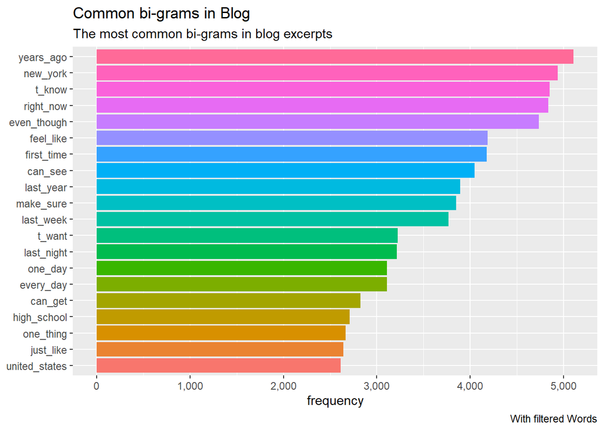

```r
# Create visualisations for bi grams

freq_bi_blog %>%
  # remove 'uninteresting' words
  # filter(2 < str_length(feature)) %>%
  filter(feature != "") %>%
  slice_head(n = 20) %>%
  mutate(feature = factor(feature),
         feature = fct_reorder(feature, frequency, min)) %>%
  ggplot(aes(x = feature, y = frequency, fill = feature)) +
  scale_y_continuous(labels = scales::comma) +
  geom_col(show.legend = FALSE) +
  coord_flip() +
  labs(title = 'Common bi-grams in Blog',
       x = NULL,
       subtitle = 'The most common bi-grams in blog excerpts',
       caption = 'With filtered Words')
```

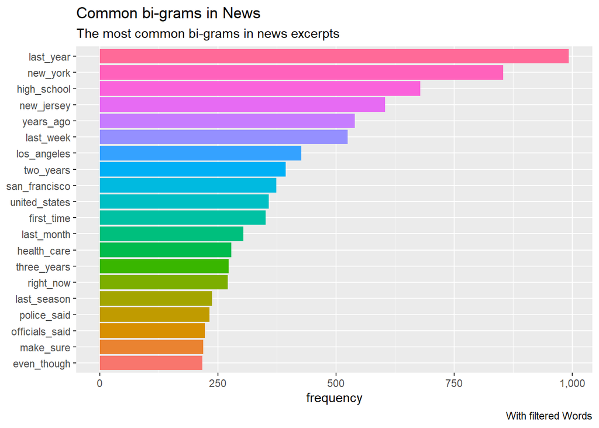

```r
freq_bi_news %>%
  # remove 'uninteresting' words
  # filter(2 < str_length(feature)) %>%
  filter(feature != "") %>%
  slice_head(n = 20) %>%
  mutate(feature = factor(feature),
         feature = fct_reorder(feature, frequency, min)) %>%
  ggplot(aes(x = feature, y = frequency, fill = feature)) +
  scale_y_continuous(labels = scales::comma) +
  geom_col(show.legend = FALSE) +
  coord_flip() +
  labs(title = 'Common bi-grams in News',
       x = NULL,
       subtitle = 'The most common bi-grams in news excerpts',
       caption = 'With filtered Words')
```

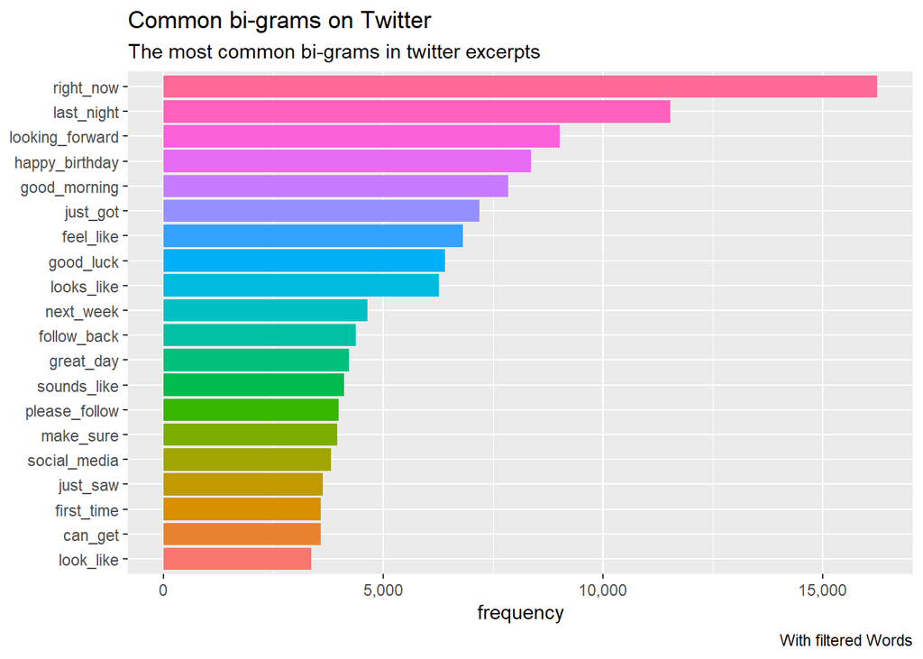

```r
freq_bi_twitter %>%
  # remove 'uninteresting' words
  # filter(2 < str_length(feature)) %>%
  filter(feature != "") %>%
  slice_head(n = 20) %>%
  mutate(feature = factor(feature),
         feature = fct_reorder(feature, frequency, min)) %>%
  ggplot(aes(x = feature, y = frequency, fill = feature)) +
  scale_y_continuous(labels = scales::comma) +
  geom_col(show.legend = FALSE) +
  coord_flip() +
  labs(title = 'Common bi-grams on Twitter',
       x = NULL,
       subtitle = 'The most common bi-grams in twitter excerpts',
       caption = 'With filtered Words')
```

Nothing sticks out with the bi-grams except for the fact we see ‘t’ paired off with words as a common occurrence in the blog excerpts. This ‘t’ could refer to ‘can’t’ or ‘don’t’ or any other kinds of contractions. We only see this high rank with the blog excerpts, but not the news or twitter excerpts. I would surmise for the news that it’s because the news does not favour contractions.

Twitter once more has very specific jargon relevant to only itself, such as ‘follow back’, or ‘please follow’.

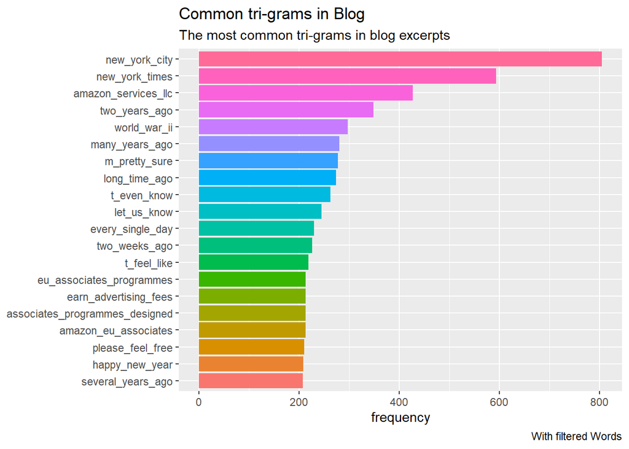

```r
# Create visualisations for tri grams

freq_tri_blog %>%
  # remove 'uninteresting' words
  # filter(2 < str_length(feature)) %>%
  filter(feature != "") %>%
  slice_head(n = 20) %>%
  mutate(feature = factor(feature),
         feature = fct_reorder(feature, frequency, min)) %>%
  ggplot(aes(x = feature, y = frequency, fill = feature)) +
  scale_y_continuous(labels = scales::comma) +
  geom_col(show.legend = FALSE) +
  coord_flip() +
  labs(title = 'Common tri-grams in Blog',
       x = NULL,
       subtitle = 'The most common tri-grams in blog excerpts',
       caption = 'With filtered Words')
```

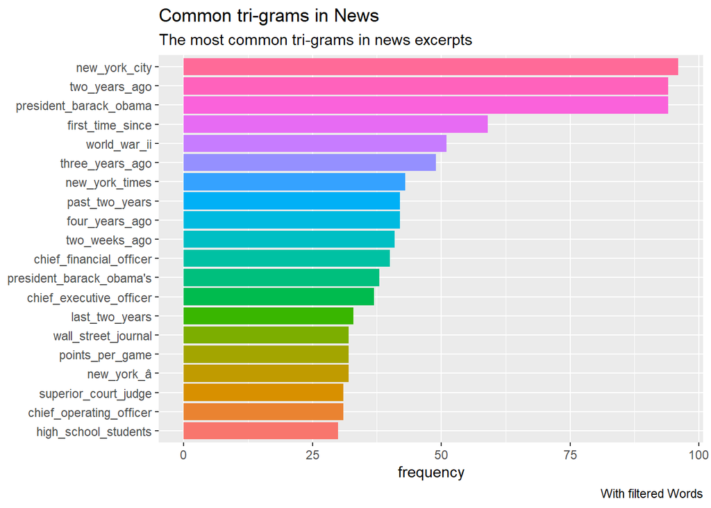

```r
freq_tri_news %>%
  # remove 'uninteresting' words
  # filter(2 < str_length(feature)) %>%
  filter(feature != "") %>%
  slice_head(n = 20) %>%
  mutate(feature = factor(feature),
         feature = fct_reorder(feature, frequency, min)) %>%
  ggplot(aes(x = feature, y = frequency, fill = feature)) +
  scale_y_continuous(labels = scales::comma) +
  geom_col(show.legend = FALSE) +
  coord_flip() +
  labs(title = 'Common tri-grams in News',
       x = NULL,
       subtitle = 'The most common tri-grams in news excerpts',
       caption = 'With filtered Words')
```

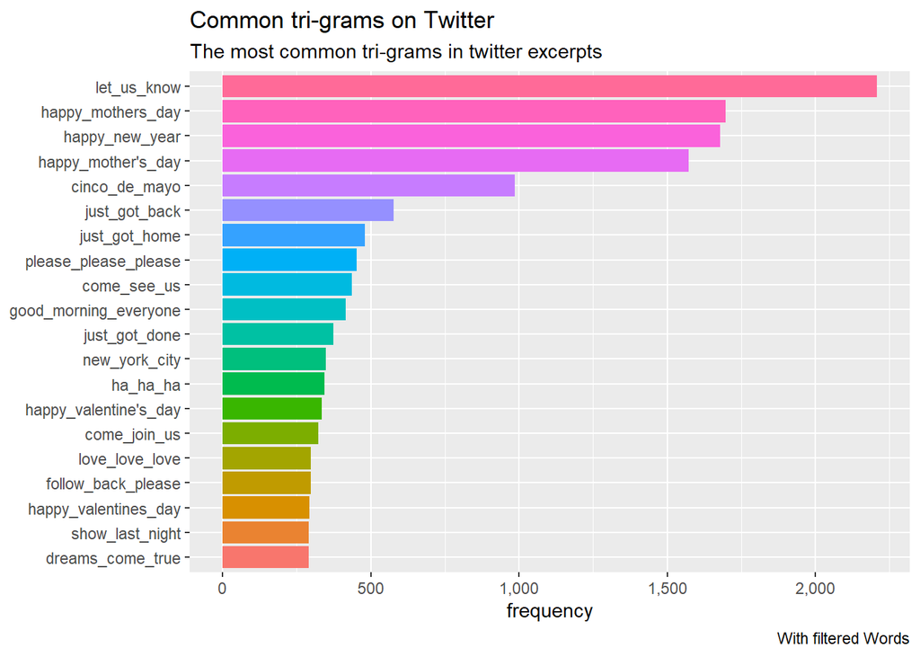

```r
freq_tri_twitter %>%
  # remove 'uninteresting' words
  # filter(2 < str_length(feature)) %>%
  filter(feature != "") %>%
  slice_head(n = 20) %>%
  mutate(feature = factor(feature),
         feature = fct_reorder(feature, frequency, min)) %>%
  ggplot(aes(x = feature, y = frequency, fill = feature)) +
  scale_y_continuous(labels = scales::comma) +
  geom_col(show.legend = FALSE) +
  coord_flip() +
  labs(title = 'Common tri-grams on Twitter',
       x = NULL,
       subtitle = 'The most common tri-grams in twitter excerpts',
       caption = 'With filtered Words')
```

In regards to the tri-grams, we see a resurgence of ‘t’ leading tri-grams. We also find repeated words as tri-grams, such as ‘ha-ha-ha’ or ‘please-please-please’, I’m currently not sure if these add any value to a prediction model.

### Initial thoughts on shiny app

In regards to modelling and the shiny app, I wish to proceed by isolating and retaining contractions as one words. Further cleaning also seems to be required as certain symbols have slipped through.

The app itself will be based on a combined corpus of the three datasets (blog, news & twitter), and use only the n-grams for prediction.

I will also need to consider a method of removing unnecessary words to enhance speed of the model. I’m on the fence with profanity being removed at this step as it seems unnecessary with it not appearing highly ranked in any of the n-grams.